© Bản quyền thuộc về Quantopian Inc.  
© Bản quyền sửa đổi thuộc về AI Cafe¹  
Giấy phép [Creative Commons Attribution 4.0](https://creativecommons.org/licenses/by/4.0/legalcode).  
[Khuyến cáo](https://aicafe.one/khuyen-cao/)

# Phân Tích Thành Phần Chính

by Rene Zhang and Max Margenot

Edited by AI Cafe¹

Được ứng dụng trong nhiều lĩnh vực, chẳng hạn như xử lý hình ảnh, sinh học thông tin và tài chính định lượng, liên quan đến dữ liệu quy mô lớn. Cả kích thước và độ phức tạp của dữ liệu này có thể khiến các phép toán cần thiết cho việc phân tích trở nên khó khả thi. Phân Tích Thành Phần Chính (PCA) là một phương pháp cổ điển cho việc giảm chiều. Nó sử dụng một số **thành phần chính** đầu tiên, các đặc trưng thống kê giải thích phần lớn biến động của ma trận dữ liệu $m \times n$ $\mathbf{X}$, để mô tả ma trận dữ liệu quy mô lớn $\mathbf{X}$ một cách hiệu quả.

```python
from numpy import linalg as LA
import numpy as np
import pandas as pd
import matplotlib.pyplot as plt
```

Chúng ta sẽ giới thiệu PCA với một ví dụ về xử lý hình ảnh. Một hình ảnh kỹ thuật số màu xám có thể được biểu diễn bằng một ma trận, trong đó phần tử $(i,j)^{th}$ tương ứng với giá trị màu xám tại pixel $(i,j)^{th}$. Hình ảnh màu xám sau đây có kích thước $200 \times 200$ pixel, mặc dù có thể thay đổi linh hoạt. Chúng ta lưu nó trong một ma trận $\mathbf{X}$. Số hàng của ma trận $\mathbf{X}$ là $200$, và số cột của ma trận $\mathbf{X}$ cũng là $200$.

```python
def generate_test_image(m,n):
    X = np.zeros((m,n))
# generate a rectangle
    X[25:80,25:80] = 1
# generate a triangle
    for i in range(25, 80, 1):
        X[i+80:160, 100+i-1] = 2
# generate a circle
    for i in range(0,200,1):
        for j in range(0,200,1):
            if ((i - 135)*(i - 135) +(j - 53)*(j - 53) <= 900):
                X[i, j] = 3
    return X
X = generate_test_image(200,200)
```

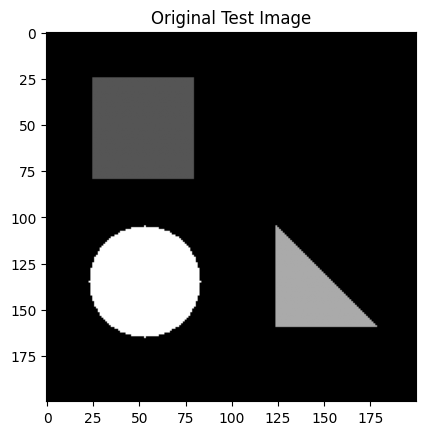

```python
imgplot = plt.imshow(X, cmap='gray')
plt.title('Original Test Image');
```

```python
m = X.shape[0] # num of rows
n = X.shape[1] # num of columns
```

Đặt mỗi hàng của ma trận $\mathbf{X}$ thành một biến, với các quan sát ở các cột. Gọi ma trận hiệp phương sai của $\mathbf{X}$ là $\mathbf{C}$, với kích thước của $\mathbf{C}$ là $m \times m$. Ma trận $\mathbf{C}$ là một ma trận mà phần tử ở vị trí $(i,j)^{th}$ là hiệp phương sai giữa hàng thứ $i$ và hàng thứ $j$ của ma trận $\mathbf{X}$.

```python
X = np.asarray(X, dtype=np.float64)
C = np.cov(X)
```

```python
np.linalg.matrix_rank(C)
```

```
np.int64(62)
```

Phân tích thành phần chính (PCA) phân rã ma trận $\mathbf{C}$ thành:

$$\mathbf{C} = \mathbf{L}\mathbf{P}\mathbf{L}^{\top},$$

trong đó $\mathbf{P}$ là một ma trận đường chéo $\mathbf{P}=\text{diag}(\lambda_1,\lambda_2,\dots,\lambda_m)$, với $\lambda_1 \geq \lambda_2 \geq \dots \geq \lambda_m \geq 0$ là các giá trị riêng của ma trận $\mathbf{C}$. Ma trận $\mathbf{L}$ là một ma trận trực giao, bao gồm các vectơ riêng của ma trận $\mathbf{C}$.

```python
P, L = LA.eigh(C)
```

Hàm `LA.eigh` liệt kê các giá trị riêng từ nhỏ đến lớn trong $P$. Hãy thay đổi thứ tự trước để liệt kê chúng từ lớn đến nhỏ và đảm bảo rằng $\mathbf{L}\mathbf{P}\mathbf{L}^{\top}==\mathbf{C}$.

```python
P = P[::-1]
L = L[:,::-1]
```

```python
np.allclose(L.dot(np.diag(P)).dot(L.T), C)
```

```
True
```

Ở đây, chúng ta sẽ vẽ tất cả các giá trị riêng:

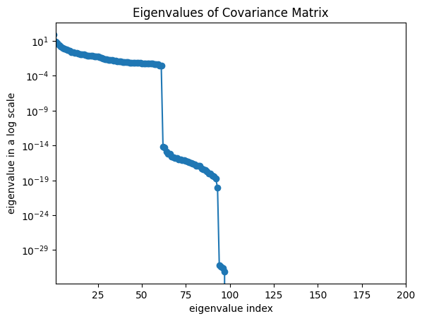

```python
plt.semilogy(P, '-o')
plt.xlim([1, P.shape[0]])
plt.xlabel('eigenvalue index')
plt.ylabel('eigenvalue in a log scale')
plt.title('Eigenvalues of Covariance Matrix');
```

Thành phần chính thứ $i^{th}$ được cho bởi hàng thứ $i^{th}$ của ma trận $\mathbf{V}$,

$$\mathbf{V} = \mathbf{L}^{\top} \mathbf{X}.$$

```python
V = L.T.dot(X)
V.shape
```

```
(200, 200)
```

Nếu chúng ta nhân cả hai bên bên trái bởi $\mathbf{L}$, chúng ta sẽ có:

$$\mathbf{L}\mathbf{L}^{\top} \mathbf{X}= \mathbf{L}\mathbf{V}.$$

Ma trận $\mathbf{L}$ là tập hợp các vectơ riêng từ một ma trận hiệp phương sai, vì vậy $\mathbf{L}\mathbf{L}^{\top} = \mathbf{I}$ và $\mathbf{L}\mathbf{L}^{\top}\mathbf{X} = \mathbf{X}$. Mối quan hệ giữa các ma trận của $\mathbf{X}$, $\mathbf{L}$, và $\mathbf{V}$ có thể được diễn đạt như sau:

$$\mathbf{X} = \mathbf{L}\mathbf{V}.$$

Để xấp xỉ $\mathbf{X}$, chúng ta sử dụng $k$ vectơ riêng có giá trị riêng lớn nhất:

$$\mathbf{X} \approx \mathbf{L[:, 1:k]}\mathbf{L[:, 1:k]}^{\top} \mathbf{X}.$$

Gọi $\tilde{\mathbf{X}}$ là xấp xỉ của $\mathbf{X}$ như sau: $\tilde{\mathbf{X}} = \mathbf{L[:, 1:k]}\mathbf{L[:, 1:k]}^{\top} \mathbf{X}$. Khi $k = m$, $\tilde{\mathbf{X}}$ sẽ giống như $\mathbf{X}$.

```python
k = 200
X_tilde =  L[:,0:k-1].dot(L[:,0:k-1].T).dot(X)
```

```python
np.allclose(X_tilde, X)
```

```
True
```

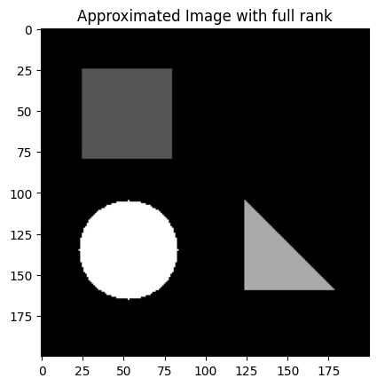

```python
plt.imshow(X_tilde, cmap='gray')
plt.title('Approximated Image with full rank');
```

Tỷ lệ của tổng phương sai do thành phần chính thứ $i^{th}$ được cho bởi tỷ lệ $\frac{\lambda_i}{\lambda_1 + \lambda_2 + \dots + \lambda_m}$. Tổng tỷ lệ của tổng phương sai nên bằng $1$. Như chúng ta đã định nghĩa, $\lambda_i$ là mục thứ $i^{th}$ của ma trận $\mathbf{P}$,

$$\sum_{i}\frac{P_i}{\text{trace}(P)} = 1$$

Trong đó trace$(P)$ là tổng của các phần tử chéo của ma trận $P$.

```python
(P/P.sum()).sum()
```

```
np.float64(1.0000000000000004)
```

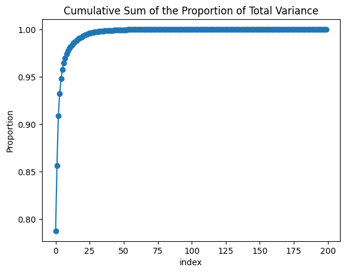

```python
plt.plot((P/P.sum()).cumsum(), '-o')
plt.title('Cumulative Sum of the Proportion of Total Variance')
plt.xlabel('index')
plt.ylabel('Proportion');
```

Số lượng thành phần chính được ký hiệu là $k$. Giả sử $k$ bằng $10, 20, 30, 60$ như các ví dụ và xem xét các hình ảnh xấp xỉ tương ứng.

```python
X_tilde_10 = L[:,0:10-1].dot(V[0:10-1,:])
X_tilde_20 = L[:,0:20-1].dot(V[0:20-1,:])
X_tilde_30 = L[:,0:30-1].dot(V[0:30-1,:])
X_tilde_60 = L[:,0:60-1].dot(V[0:60-1,:])
```

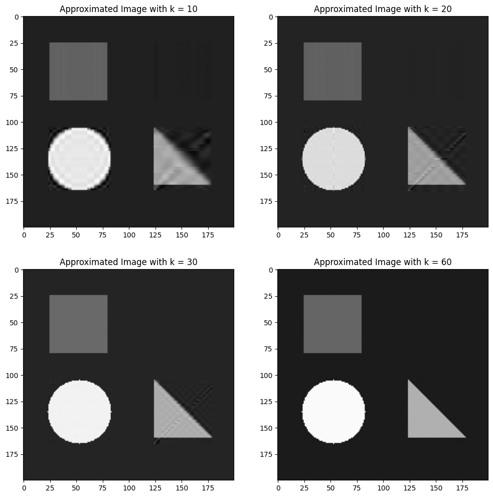

```python
fig, ((ax1, ax2), (ax3, ax4)) = plt.subplots(2, 2, figsize=(12, 12))
ax1.imshow(X_tilde_10, cmap='gray')
ax1.set(title='Approximated Image with k = 10')
ax2.imshow(X_tilde_20, cmap='gray')
ax2.set(title='Approximated Image with k = 20')
ax3.imshow(X_tilde_30, cmap='gray')
ax3.set(title='Approximated Image with k = 30')
ax4.imshow(X_tilde_60, cmap='gray')
ax4.set(title='Approximated Image with k = 60');
```

Tiếp theo, chúng ta không cần phải thực hiện PCA bằng tay. [Scikit-learn](http://scikit-learn.org/stable/modules/generated/sklearn.decomposition.PCA.html) có hàm cho PCA mà chúng ta có thể sử dụng. Tiếp theo, chúng ta cùng xem một ví dụ trong tài chính định lượng sử dụng sklearn.

## PCA cho danh mục

Xây dựng một danh mục đầu tư với 10 cổ phiếu: ACB, CTG, MBB, BID, VCB, DIG, VIC, NVL, NLG, HDC. Trong số đó, 5 cổ phiếu liên quan đến ngân hàng và 5 cổ phiếu liên quan đến bất động sản.

Trong trường hợp này, có 10 biến (công ty), và mỗi cột là một biến.

```python
# Cài thư viện lấy dữ liệu miễn phí
!curl -fsSLO https://raw.githubusercontent.com/algo-stocks/data/master/data.py
```

```python
from data import get_prices

start = '2023-01-01'
end = '2025-01-01'

symbols = ['ACB', 'CTG', 'MBB', 'BID', 'VCB', 'DIG', 'VIC', 'NVL', 'NLG', 'HDC']

portfolio_returns = get_prices(*symbols, start_date=start, end_date=end).pct_change()[1:]
```

```python
from sklearn.decomposition import PCA
num_pc = 2

X = np.asarray(portfolio_returns)
[n,m] = X.shape
print('The number of timestamps is {}.'.format(n))
print('The number of stocks is {}.'.format(m))

pca = PCA(n_components=num_pc) # number of principal components
pca.fit(X)

percentage =  pca.explained_variance_ratio_
percentage_cum = np.cumsum(percentage)
print('{0:.2f}% of the variance is explained by the first 2 PCs'.format(percentage_cum[-1]*100))

pca_components = pca.components_
```

```
The number of timestamps is 498.
The number of stocks is 10.
64.25% of the variance is explained by the first 2 PCs
```

Lưu ý rằng phần lớn biến động của lợi nhuận từ các tài sản này có thể được giải thích bởi hai thành phần chính đầu tiên.

Bây giờ chúng ta sẽ thu thập hai thành phần chính đầu tiên và vẽ biểu đồ sự đóng góp của chúng.

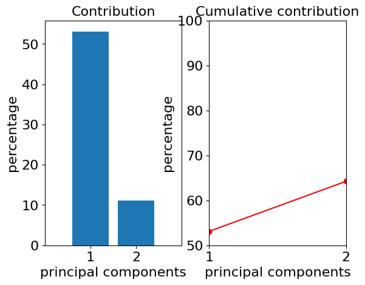

```python
x = np.arange(1,len(percentage)+1,1)

plt.subplot(1, 2, 1)
plt.bar(x, percentage*100, align = "center")
plt.title('Contribution',fontsize = 16)
plt.xlabel('principal components',fontsize = 16)
plt.ylabel('percentage',fontsize = 16)
plt.xticks(x,fontsize = 16)
plt.yticks(fontsize = 16)
plt.xlim([0, num_pc+1])

plt.subplot(1, 2, 2)
plt.plot(x, percentage_cum*100,'ro-')
plt.xlabel('principal components',fontsize = 16)
plt.ylabel('percentage',fontsize = 16)
plt.title('Cumulative contribution',fontsize = 16)
plt.xticks(x,fontsize = 16)
plt.yticks(fontsize = 16)
plt.xlim([1, num_pc])
plt.ylim([50,100]);
```

Từ những thành phần chính này, chúng ta có thể xây dựng "các yếu tố rủi ro thống kê", tương tự như các yếu tố rủi ro thông thường hơn. Những yếu tố này sẽ giúp chúng ta có được một ý tưởng về việc bao nhiêu phần trăm lợi nhuận của danh mục đầu tư đến từ một số đặc điểm thống kê không thể quan sát được.

```python
factor_returns = X.dot(pca_components.T)
factor_returns = pd.DataFrame(columns=["factor 1", "factor 2"],
                              index=portfolio_returns.index,
                              data=factor_returns)
factor_returns.head()
```

| date | factor 1 | factor 2 |
| --- | --- | --- |
| 2023-01-04 | -0.020298 | 0.015467 |
| 2023-01-05 | -0.004405 | 0.018399 |
| 2023-01-06 | -0.016482 | 0.030769 |
| 2023-01-09 | -0.029606 | 0.000981 |
| 2023-01-10 | -0.008860 | -0.011674 |

Các yếu tố trả ở đây tương tự như ma trận thành phần chính $\mathbf{V}$ trong ví dụ xử lý hình ảnh.

```python
factor_exposures = pd.DataFrame(index=["factor 1", "factor 2"],
                                columns=portfolio_returns.columns,
                                data = pca.components_).T
```

```python
factor_exposures
```

|  | factor 1 | factor 2 |
| --- | --- | --- |
| ACB | 0.142281 | 0.304617 |
| CTG | 0.185092 | 0.482357 |
| MBB | 0.181013 | 0.391539 |
| BID | 0.166310 | 0.444317 |
| VCB | 0.065433 | 0.230405 |
| DIG | 0.532935 | -0.227488 |
| VIC | 0.171637 | 0.059680 |
| NVL | 0.462118 | -0.460995 |
| NLG | 0.415195 | 0.043768 |
| HDC | 0.425878 | 0.031438 |

Các yếu tố tiếp xúc là một phép tương tự với ma trận eigenvector $\mathbf{L}$ trong ví dụ xử lý hình ảnh.

```python
labels = factor_exposures.index
data = factor_exposures.values
```

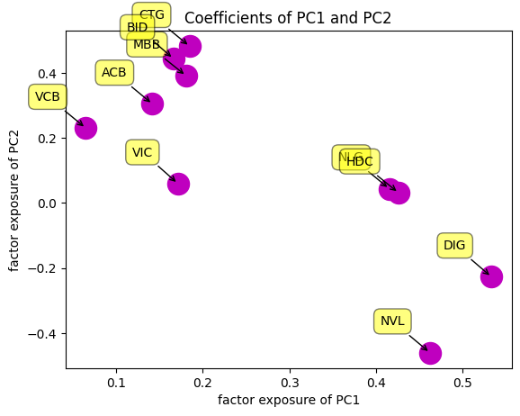

```python
plt.subplots_adjust(bottom = 0.1)
plt.scatter(
    data[:, 0], data[:, 1], marker='o', s=300, c='m')
plt.title('Coefficients of PC1 and PC2')
plt.xlabel('factor exposure of PC1')
plt.ylabel('factor exposure of PC2')

for label, x, y in zip(labels, data[:, 0], data[:, 1]):
    plt.annotate(
        label,
        xy=(x, y), xytext=(-20, 20),
        textcoords='offset points', ha='right', va='bottom',
        bbox=dict(boxstyle='round,pad=0.5', fc='yellow', alpha=0.5),
        arrowprops=dict(arrowstyle = '->', connectionstyle='arc3,rad=0')
    );
```

Việc tạo ra các yếu tố rủi ro thống kê cho phép chúng ta phân tích thêm lợi nhuận của một danh mục đầu tư để hiểu rõ hơn về rủi ro. Điều này có thể được sử dụng như một bước bổ sung sau khi phân tích hiệu suất với các yếu tố rủi ro phổ biến hơn nhằm cố gắng tính đến các rủi ro không xác định khác.

## Tham khảo

- Datta, B.N., 2010. *Numerical linear algebra and applications*. Siam.
- Qian, E.E., Hua, R.H. and Sorensen, E.H., 2007. *Quantitative equity portfolio management: modern techniques and applications*. CRC Press.

*Lưu ý: Tài liệu này mang tính chất chia sẻ kiến thức khoa học dữ liệu. Các mã chứng khoán xuất hiện trong tài liệu chỉ mang tính chất minh hoạ, không khuyến nghị đầu tư. Chúng tôi không chịu trách nhiệm trước mọi rủi ro nào do sử dụng tài liệu này.*